# Explore the world with R

Your browser **doesn't support the features required** by impress.js, so you are presented with a simplified version of this presentation.

For the best experience please use the latest **Chrome**, **Safari** or **Firefox** browser.

Explore the world with

[figure not shown]

Taiwan R user Group

**陳奎銘 (Ben)** benjamin0901@gmail.com

**陳奎銘(Ben)**

**學歷**

- 陽明大學醫學放射技術學系
- 陽明大學生物醫學資訊研究所

**工作經歷**

- 和鑫生技開發股份有限公司研發工程師
- Taiwan R user group officer
- 普生股份有限公司研發工程師

**程式語言：**R & Matlab

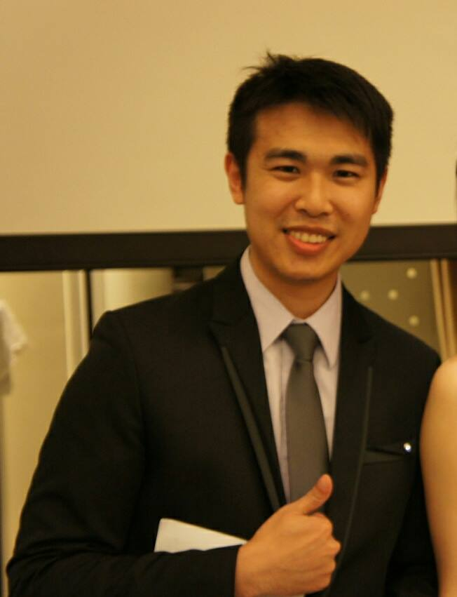

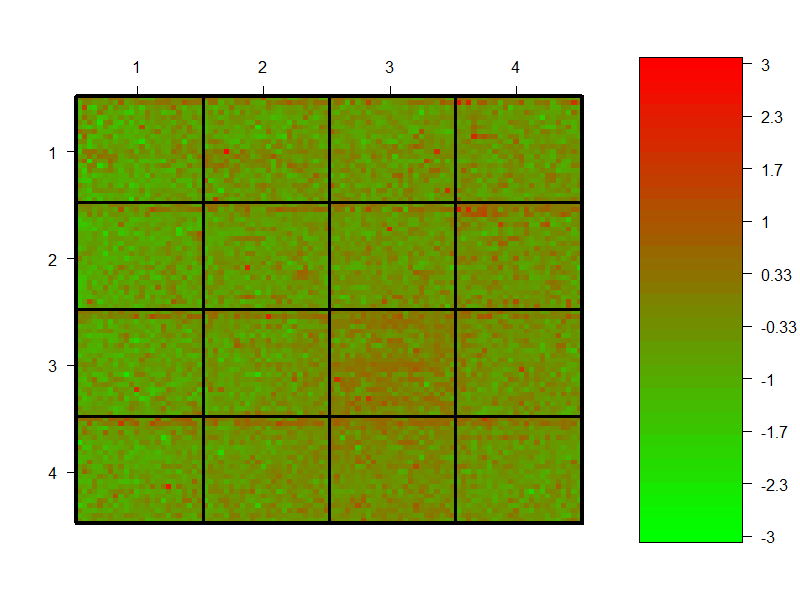

R的推廣經歷

**2005/??**

- R的初體驗

**2012/10**

- 加入Taiwan R User Group

**2013/08**

- Coscup

**2013/11**

- 中興大學 OSSF

**2014/01**

- 中研院 OSSF

**2014/08**

- 2014/08-- 資料科學愛好者年會

What's R

language and enviroment for statistical computing and graphics

Why R

**強大的視覺化效果**

[figure not shown]

圖片來源：http://www.r-bloggers.com/mapping-the-worlds-biggest-airlines/

**大量套件支援**

[figure not shown]

圖片來源：http://blog.revolutionanalytics.com/2013/11/cran-now-has-5000-r-packages.html

**使用者眾**

[figure not shown]

圖片來源：https://www.kaggle.com/wiki/Software

**輕易與其他工具整合**

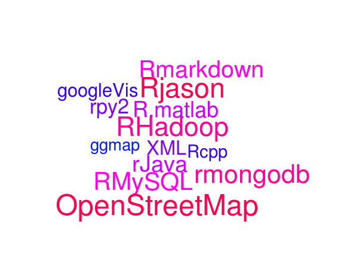

# 實際案例

# 小明想要找個女朋友....

# Ptt

# Alltogether

**但是，有些文章還沒看就被刪了...**

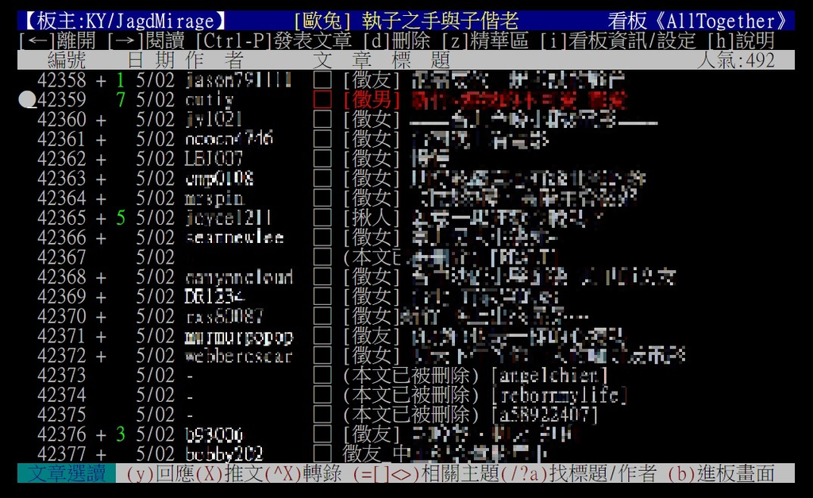

**找出女孩們最常PO文的時間！**

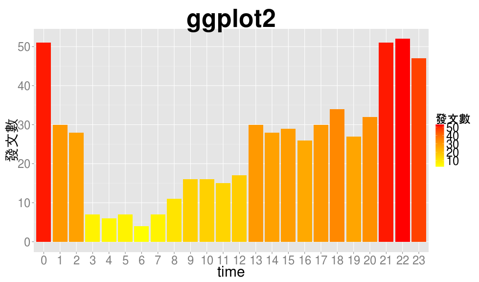

**一直會看到薪水相關的新聞**

[figure not shown]

**震驚！台灣公開薪資數據！**

[interactive chart not shown]

**歷年薪資分佈(googleVis)**

[interactive chart not shown]

報告

**markdown with R**

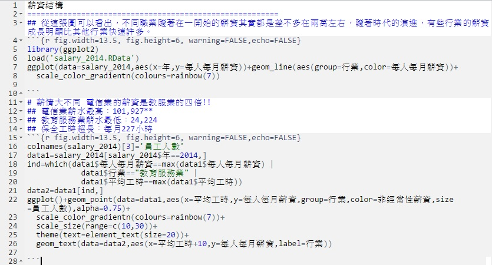

**markdown with R**

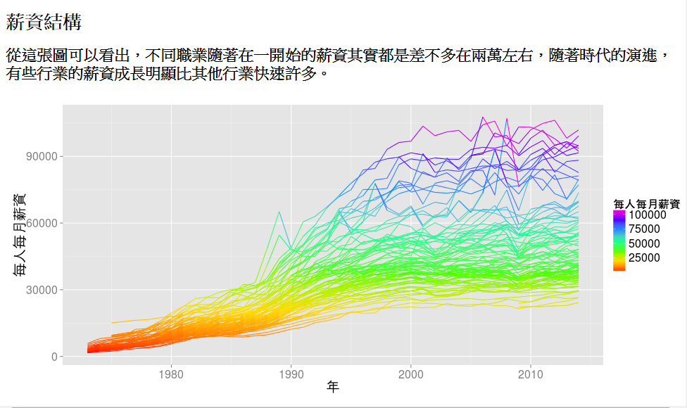

**R skills attract the highest salaries**

[figure not shown]

圖片來源：http://a2.typepad.com/6a0105360ba1c6970c01a73d7580ea970d-pi

公司希望利用各種biomarker建立一個預測肝纖維化的model

**利用各種Data Mining的套件**

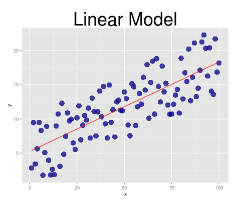

[figure not shown]

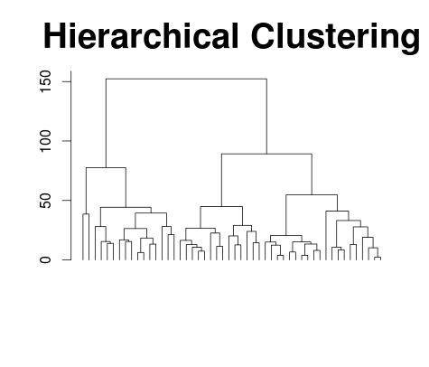

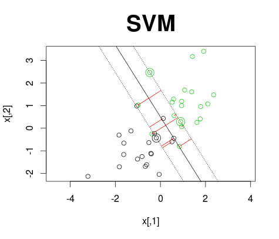

# 以Shiny提供App服務

[interactive chart not shown]

**Data Science**

[figure not shown]

圖片來源：http://www.datasciencecentral.com/profiles/blogs/data-scientist-core-skills

教學資源  
Cook Book for R:  
http://www.cookbook-r.com/  
Cheat Sheets: http://www.rstudio.com/resources/cheatsheets/  
Taiwan R User Group  
資料分析上手課程: http://taiwanrusergroup.github.io/DSC2014Tutorial/  
MLDM Monday: https://www.youtube.com/user/TWuseRGroup

[figure not shown]

Use a spacebar or arrow keys to navigate